# Module Nine Project

For the module nine project you are required to produce coding samples in accordance with the requirements in the project guidelines and rubric. This Notebook has been pre-created as a shell for your project submission.

Once your code is complete, you will download this notebook as an HTML file by clicking **File**, then **Download As**, then **HTML (.html)** from the Jupyter menu bar. Validate that your code and outputs are rendered in the html file before submission.

*Missing Blocks:* Ensure that you have clicked **Run** for all blocks before downloading as an HTML file or the block may be missing from your submission.

### Data Source Information

Below are some example reputable data sources that you can use to collect your minimum of two data sets from:

- https://datasetsearch.research.google.com/
- https://www.kaggle.com/datasets
- https://data.gov/
- https://www.census.gov/data.html
- https://www.bls.gov/data/
- https://databank.worldbank.org/databases
- https://www.ncei.noaa.gov/access/search/index
- https://www.epa.gov/data
- https://www.pewresearch.org/tools-and-datasets/
- https://www.who.int/data/
- https://dataverse.harvard.edu/
- https://search.cdc.gov/search/?query=dataset&dpage=1
- https://data.fivethirtyeight.com/
- https://www.gdeltproject.org/data.html
- https://datahub.io/collections

**Note: this list is not all inclusive, if you have a reputable data set that you have collected, or would like to use, please ensure to upload the data. All data sets will need to be documented in your submission as to the source through the creation of a citation.**

*To Begin:* replace each **data_file_#** entry sample data path with the path to your selected data sets.

You are welcome to use more than two data sets, create an entry for each as applicable for each data set. Ensure that you create comments that provide citations for the data sets you have selected for use. When working through your submission, keep in mind that you will need to have choosen two separate groups of stakeholders to create your final visualizations.

```python
# =============================================================================
# Data Source Citations
# =============================================================================
# All three data sets were provided through the SNHU CS-540 Codio environment
# and originate from the U.S. Department of Agriculture, Economic Research
# Service (USDA ERS) County-Level Data Sets.
#
# U.S. Department of Agriculture, Economic Research Service. (2023).
#   County-Level Data Sets: Education. Retrieved from Codio course materials,
#   SNHU CS-540 Data Literacy & Visualization.
#
# U.S. Department of Agriculture, Economic Research Service. (2023).
#   County-Level Data Sets: Unemployment and Median Household Income.
#   Retrieved from Codio course materials, SNHU CS-540 Data Literacy
#   & Visualization.
#
# U.S. Department of Agriculture, Economic Research Service. (2023).
#   County-Level Data Sets: Population Estimates. Retrieved from Codio course
#   materials, SNHU CS-540 Data Literacy & Visualization.
# =============================================================================

data_file_1 = "data/Education2023.csv"        # Educational attainment data
data_file_2 = "data/Unemployment2023.csv"     # Labor force, unemployment, income
data_file_3 = "data/PopulationEstimates.csv"  # Population, births, deaths, migration
```

## Installing Required Packages

If you have additional packages that you would like to use or install, add them to the **requirements.txt** file then run the next two blocks.

```python
%pip install --upgrade pip
```

```python
%pip install -r requirements.txt
```

## Import the Required Packages

```python
# Core data handling
import pandas as pd
import numpy as np

# Visualization libraries
import matplotlib.pyplot as plt
import seaborn as sns

# Display configuration
pd.set_option('display.max_columns', 100)
pd.set_option('display.width', 200)

# Set a consistent visualization style
sns.set_style("whitegrid")
plt.rcParams['figure.figsize'] = (12, 6)
plt.rcParams['font.size'] = 11

print("All packages imported successfully.")
print(f"pandas version: {pd.__version__}")
print(f"numpy version:  {np.__version__}")
```

```
All packages imported successfully.
pandas version: 3.0.3
numpy version:  2.4.5
```

## Loading the Data

Create entries to load your data for your submission.

```python
# Load each of the three data sets into a separate DataFrame
education_df = pd.read_csv(data_file_1)
unemployment_df = pd.read_csv(data_file_2)
population_df = pd.read_csv(data_file_3)

# Confirm the data loaded by printing the shape of each DataFrame
print(f"Education data shape:    {education_df.shape}")
print(f"Unemployment data shape: {unemployment_df.shape}")
print(f"Population data shape:   {population_df.shape}")
```

```
Education data shape:    (432, 5)
Unemployment data shape: (1184, 5)
Population data shape:   (3238, 5)
```

## Examining the Data

Create entries to conduct exploratory data analysis to identify key data points to include relevant data from your two data sets while evaluating the quality of your choosen data.

```python
# Helper function to summarize each DataFrame consistently
def summarize(df, name):
    print("=" * 70)
    print(f"  {name}")
    print("=" * 70)
    print(f"Shape: {df.shape}  (rows x columns)")
    print(f"Columns: {list(df.columns)}")
    print(f"\nData types:\n{df.dtypes.to_string()}")
    print(f"\nMissing values per column:\n{df.isnull().sum().to_string()}")
    print(f"\nDuplicated rows: {df.duplicated().sum()}")
    print()
    display(df.head())
    print()

summarize(education_df,    "EDUCATION (Educational attainment, 2019-2023)")
summarize(unemployment_df, "UNEMPLOYMENT (Labor force & income, 2019-2023)")
summarize(population_df,   "POPULATION (Estimates & migration, 2020-2023)")
```

```
======================================================================
  EDUCATION (Educational attainment, 2019-2023)
======================================================================
Shape: (432, 5)  (rows x columns)
Columns: ['FIPS Code', 'State', 'Area name', 'Attribute', 'Value']

Data types:
FIPS Code      int64
State            str
Area name        str
Attribute        str
Value        float64

Missing values per column:
FIPS Code    0
State        0
Area name    0
Attribute    0
Value        0

Duplicated rows: 0
```

|  | FIPS Code | State | Area name | Attribute | Value |
| --- | --- | --- | --- | --- | --- |
| 0 | 0 | US | United States | Less than high school graduate, 2019-23 | 2.423022e+07 |
| 1 | 0 | US | United States | High school graduate (or equivalency), 2019-23 | 5.983649e+07 |
| 2 | 0 | US | United States | Some college or associate degree, 2019-23 | 6.441365e+07 |
| 3 | 0 | US | United States | Bachelor's degree or higher, 2019-23 | 7.995430e+07 |
| 4 | 0 | US | United States | Percent of adults who are not high school grad... | 1.060707e+01 |

```
======================================================================
  UNEMPLOYMENT (Labor force & income, 2019-2023)
======================================================================
Shape: (1184, 5)  (rows x columns)
Columns: ['FIPS_Code', 'State', 'Area_Name', 'Attribute', 'Value']

Data types:
FIPS_Code      int64
State            str
Area_Name        str
Attribute        str
Value        float64

Missing values per column:
FIPS_Code    0
State        0
Area_Name    0
Attribute    0
Value        0

Duplicated rows: 0
```

|  | FIPS_Code | State | Area_Name | Attribute | Value |
| --- | --- | --- | --- | --- | --- |
| 0 | 0 | US | United States | Civilian_labor_force_2019 | 163815894.0 |
| 1 | 0 | US | United States | Employed_2019 | 157805901.0 |
| 2 | 0 | US | United States | Unemployed_2019 | 6009993.0 |
| 3 | 0 | US | United States | Unemployment_rate_2019 | 3.7 |
| 4 | 0 | US | United States | Civilian_labor_force_2020 | 161131754.0 |

```
======================================================================
  POPULATION (Estimates & migration, 2020-2023)
======================================================================
Shape: (3238, 5)  (rows x columns)
Columns: ['FIPStxt', 'State', 'Area_Name', 'Attribute', 'Value']

Data types:
FIPStxt        int64
State            str
Area_Name        str
Attribute        str
Value        float64

Missing values per column:
FIPStxt      0
State        0
Area_Name    0
Attribute    0
Value        0

Duplicated rows: 0
```

|  | FIPStxt | State | Area_Name | Attribute | Value |
| --- | --- | --- | --- | --- | --- |
| 0 | 0 | US | United States | CENSUS_2020_POP | 331449281.0 |
| 1 | 0 | US | United States | ESTIMATES_BASE_2020 | 331464948.0 |
| 2 | 0 | US | United States | POP_ESTIMATE_2020 | 331526933.0 |
| 3 | 0 | US | United States | POP_ESTIMATE_2021 | 332048977.0 |
| 4 | 0 | US | United States | POP_ESTIMATE_2022 | 333271411.0 |

```python
# Examine the unique attributes in each long-format dataset.
# Each row in these files represents one (area, attribute) pair,
# so the "Attribute" column tells us what variables are actually stored.

print("EDUCATION ATTRIBUTES")
print(f"  Total unique attributes: {education_df['Attribute'].nunique()}")
for a in education_df['Attribute'].unique():
    print(f"   - {a}")

print(f"\nUNEMPLOYMENT ATTRIBUTES")
print(f"  Total unique attributes: {unemployment_df['Attribute'].nunique()}")
for a in unemployment_df['Attribute'].unique():
    print(f"   - {a}")

print(f"\nPOPULATION ATTRIBUTES")
print(f"  Total unique attributes: {population_df['Attribute'].nunique()}")
for a in population_df['Attribute'].unique():
    print(f"   - {a}")
```

```
EDUCATION ATTRIBUTES
  Total unique attributes: 8
   - Less than high school graduate, 2019-23
   - High school graduate (or equivalency), 2019-23
   - Some college or associate degree, 2019-23
   - Bachelor's degree or higher, 2019-23
   - Percent of adults who are not high school graduates, 2019-23
   - Percent of adults who are high school graduates (or equivalent), 2019-23
   - Percent of adults completing some college or associate degree, 2019-23
   - Percent of adults with a bachelor's degree or higher, 2019-23

UNEMPLOYMENT ATTRIBUTES
  Total unique attributes: 25
   - Civilian_labor_force_2019
   - Employed_2019
   - Unemployed_2019
   - Unemployment_rate_2019
   - Civilian_labor_force_2020
   - Employed_2020
   - Unemployed_2020
   - Unemployment_rate_2020
   - Civilian_labor_force_2021
   - Employed_2021
   - Unemployed_2021
   - Unemployment_rate_2021
   - Civilian_labor_force_2022
   - Employed_2022
   - Unemployed_2022
   - Unemployment_rate_2022
   - Civilian_labor_force_2023
   - Employed_2023
   - Unemployed_2023
   - Unemployment_rate_2023
   - Median_Household_Income_2022
   - Med_HH_Income_Percent_of_State_Total_2022
   - Rural_Urban_Continuum_Code_2023
   - Urban_Influence_Code_2013
   - Metro_2023

POPULATION ATTRIBUTES
```

[output cut: 155 more lines]

```
   - R_DOMESTIC_MIG_2021
   - R_DOMESTIC_MIG_2022
   - R_DOMESTIC_MIG_2023
   - R_NET_MIG_2021
   - R_NET_MIG_2022
   - R_NET_MIG_2023
   - GQ_ESTIMATES_BASE_2020
   - GQ_ESTIMATES_2020
   - GQ_ESTIMATES_2021
   - GQ_ESTIMATES_2022
   - GQ_ESTIMATES_2023
   - Rural_Urban_Continuum_Code_2013
   - Rural_Urban_Continuum_Code_2023
   - Urban_Influence_2013
   - Economic_typology_2015
```

### Data Quality Observations

Based on the exploratory analysis above, several important characteristics emerge:

**Structural observations:**

- All three data sets are in **long format** — each row represents a single attribute/value pair for one geographic area. We will need to pivot them to wide format before merging.
- The three files use **inconsistent column names** for the same conceptual fields:
  - FIPS identifier: `FIPS Code` (Education) vs `FIPS_Code` (Unemployment) vs `FIPStxt` (Population)
  - Area label: `Area name` (Education) vs `Area_Name` (Unemployment and Population)
- We will need to standardize these column names before blending.

**Coverage observations:**

- The Education file contains educational attainment estimates pooled over the 2019–23 period (8 attributes: 4 raw counts + 4 percentages).
- The Unemployment file covers a 5-year span (2019–2023) with annual labor-force, employment, unemployment, and rate values, plus 2022 median household income.
- The Population file covers a 4-year span (2020–2023) with births, deaths, migration, and population estimates.
- All three files operate at the **state level** (approximately 54 areas: U.S. total + 50 states + DC + territories).

These observations directly shape the preprocessing strategy in the next section.

## Data Preprocessing Techniques

Create entries to clean and blend your data sets as applicable consolidating the two or more data sets into a single collection for inclusion into your visualizations.

```python
# ---------------------------------------------------------------------------
# Step 1: Standardize column names so the three sources share a common key
# ---------------------------------------------------------------------------
education_df = education_df.rename(columns={
    "FIPS Code": "FIPS",
    "Area name": "Area_Name"
})

unemployment_df = unemployment_df.rename(columns={
    "FIPS_Code": "FIPS"
})

population_df = population_df.rename(columns={
    "FIPStxt": "FIPS"
})

# ---------------------------------------------------------------------------
# Step 2: Pivot each long-format data set into wide format
# ---------------------------------------------------------------------------
# After pivoting, each row will represent one geographic area and each
# Attribute becomes its own column.

def pivot_to_wide(df):
    wide = df.pivot_table(
        index=["FIPS", "State", "Area_Name"],
        columns="Attribute",
        values="Value",
        aggfunc="first"
    ).reset_index()
    wide.columns.name = None   # drop the leftover "Attribute" axis label
    return wide

education_wide    = pivot_to_wide(education_df)
unemployment_wide = pivot_to_wide(unemployment_df)
population_wide   = pivot_to_wide(population_df)

print(f"Education (wide):    {education_wide.shape}")
print(f"Unemployment (wide): {unemployment_wide.shape}")
print(f"Population (wide):   {population_wide.shape}")
```

```
Education (wide):    (54, 11)
Unemployment (wide): (54, 28)
Population (wide):   (54, 68)
```

```python
# ---------------------------------------------------------------------------
# Step 3: Blend the three wide-format data sets into a single table
# ---------------------------------------------------------------------------
# Outer-join on the shared keys so no area is lost if it's missing from a file.

merged_df = (
    unemployment_wide
    .merge(population_wide, on=["FIPS", "State", "Area_Name"], how="outer")
    .merge(education_wide,  on=["FIPS", "State", "Area_Name"], how="outer")
)

print(f"Final merged shape: {merged_df.shape}  (rows x columns)")
print(f"Total columns:      {len(merged_df.columns)}")
print(f"\nFirst few rows of the merged data:")
display(merged_df.head())

# Quick verification: list a sample of available columns
print("\nA sample of available columns:")
print(list(merged_df.columns)[:20], "...")
```

```
Final merged shape: (54, 101)  (rows x columns)
Total columns:      101

First few rows of the merged data:
```

|  | FIPS | State | Area_Name | Civilian_labor_force_2019 | Civilian_labor_force_2020 | Civilian_labor_force_2021 | Civilian_labor_force_2022 | Civilian_labor_force_2023 | Employed_2019 | Employed_2020 | Employed_2021 | Employed_2022 | Employed_2023 | Med_HH_Income_Percent_of_State_Total_2022 | Median_Household_Income_2022 | Metro_2023 | Rural_Urban_Continuum_Code_2023_x | Unemployed_2019 | Unemployed_2020 | Unemployed_2021 | Unemployed_2022 | Unemployed_2023 | Unemployment_rate_2019 | Unemployment_rate_2020 | Unemployment_rate_2021 | Unemployment_rate_2022 | Unemployment_rate_2023 | Urban_Influence_Code_2013 | BIRTHS_2020 | … |
| --- | --- | --- | --- | --- | --- | --- | --- | --- | --- | --- | --- | --- | --- | --- | --- | --- | --- | --- | --- | --- | --- | --- | --- | --- | --- | --- | --- | --- | --- | --- |
| 0 | 0 | US | United States | 163815894.0 | 161131754.0 | 161784447.0 | 164341251.0 | 166689556.0 | 157805901.0 | 148133696.0 | 153122706.0 | 158342285.0 | 160623678.0 | NaN | 74755.0 | NaN | NaN | 6009993.0 | 12998058.0 | 8661741.0 | 5998966.0 | 6065878.0 | 3.7 | 8.1 | 5.4 | 3.7 | 3.6 | NaN | 894123.0 | … |
| 1 | 1000 | AL | Alabama | 2271835.0 | 2263144.0 | 2249514.0 | 2276362.0 | 2308131.0 | 2199379.0 | 2118600.0 | 2173978.0 | 2218627.0 | 2250472.0 | 100.0 | 59703.0 | NaN | NaN | 72456.0 | 144544.0 | 75536.0 | 57735.0 | 57659.0 | 3.2 | 6.4 | 3.4 | 2.5 | 2.5 | NaN | 13867.0 | … |
| 2 | 2000 | AK | Alaska | 352029.0 | 346552.0 | 351520.0 | 353692.0 | 357094.0 | 332197.0 | 317678.0 | 329147.0 | 338729.0 | 342005.0 | 100.0 | 88072.0 | NaN | NaN | 19832.0 | 28874.0 | 22373.0 | 14963.0 | 15089.0 | 5.6 | 8.3 | 6.4 | 4.2 | 4.2 | NaN | 2406.0 | … |
| 3 | 4000 | AZ | Arizona | 3432400.0 | 3471339.0 | 3525449.0 | 3599531.0 | 3690974.0 | 3267548.0 | 3200219.0 | 3347264.0 | 3462671.0 | 3546508.0 | 100.0 | 74355.0 | NaN | NaN | 164852.0 | 271120.0 | 178185.0 | 136860.0 | 144466.0 | 4.8 | 7.8 | 5.1 | 3.8 | 3.9 | NaN | 18110.0 | … |
| 4 | 5000 | AR | Arkansas | 1353175.0 | 1340557.0 | 1330676.0 | 1359540.0 | 1377657.0 | 1305858.0 | 1257949.0 | 1276933.0 | 1315886.0 | 1332876.0 | 100.0 | 55505.0 | NaN | NaN | 47317.0 | 82608.0 | 53743.0 | 43654.0 | 44781.0 | 3.5 | 6.2 | 4.0 | 3.2 | 3.3 | NaN | 8509.0 | … |

5 rows × 101 columns

```
A sample of available columns:
['FIPS', 'State', 'Area_Name', 'Civilian_labor_force_2019', 'Civilian_labor_force_2020', 'Civilian_labor_force_2021', 'Civilian_labor_force_2022', 'Civilian_labor_force_2023', 'Employed_2019', 'Employed_2020', 'Employed_2021', 'Employed_2022', 'Employed_2023', 'Med_HH_Income_Percent_of_State_Total_2…
```

```python
# ---------------------------------------------------------------------------
# Step 4: Handle missing values and engineer features for the analysis
# ---------------------------------------------------------------------------

# Check missing values in the merged data
missing_summary = merged_df.isnull().sum().sort_values(ascending=False)
print("Columns with the most missing values (top 10):")
print(missing_summary[missing_summary > 0].head(10).to_string())

# Create a state-level frame (drop the U.S. national row, FIPS == 0)
states_df = merged_df[merged_df["FIPS"] != 0].copy()

# --- Engineered features ---
# Population growth from 2020 census to 2023 estimate (%)
states_df["Pop_Change_Pct_2020_2023"] = (
    (states_df["POP_ESTIMATE_2023"] - states_df["CENSUS_2020_POP"])
    / states_df["CENSUS_2020_POP"] * 100
)

# Change in unemployment rate from 2019 (pre-pandemic) to 2023
states_df["Unemployment_Change_2019_2023"] = (
    states_df["Unemployment_rate_2023"] - states_df["Unemployment_rate_2019"]
)

# Composite "Expansion Attractiveness" score for the executive audience.
# Higher bachelor's-degree %, lower unemployment, and positive population
# growth all push the score upward. Each input is min-max normalized.
def normalize(series):
    return (series - series.min()) / (series.max() - series.min())

states_df["Expansion_Score"] = (
    normalize(states_df["Percent of adults with a bachelor's degree or higher, 2019-23"])
    + normalize(-states_df["Unemployment_rate_2023"])
    + normalize(states_df["Pop_Change_Pct_2020_2023"])
) / 3

print(f"\nState-level frame shape: {states_df.shape}")
print("\nSample of new engineered columns:")
display(
    states_df[["State", "Area_Name",
               "Pop_Change_Pct_2020_2023",
               "Unemployment_Change_2019_2023",
               "Expansion_Score"]]
    .sort_values("Expansion_Score", ascending=False)
    .head(10)
)
```

```
Columns with the most missing values (top 10):
Economic_typology_2015                       53
Rural_Urban_Continuum_Code_2023_y            53
Urban_Influence_Code_2013                    53
Rural_Urban_Continuum_Code_2013              53
Rural_Urban_Continuum_Code_2023_x            53
Metro_2023                                   53
Urban_Influence_2013                         53
GQ_ESTIMATES_BASE_2020                        2
Med_HH_Income_Percent_of_State_Total_2022     2
GQ_ESTIMATES_2023                             2

State-level frame shape: (53, 104)

Sample of new engineered columns:
```

|  | State | Area_Name | Pop_Change_Pct_2020_2023 | Unemployment_Change_2019_2023 | Expansion_Score |
| --- | --- | --- | --- | --- | --- |
| 46 | UT | Utah | 4.466233 | 0.1 | 0.641966 |
| 14 | ID | Idaho | 6.830493 | 0.2 | 0.632035 |
| 43 | SD | South Dakota | 3.682442 | -0.8 | 0.617551 |
| 47 | VT | Vermont | 0.682189 | -0.1 | 0.612425 |
| 31 | NH | New Hampshire | 1.780362 | -0.4 | 0.609278 |
| 11 | FL | Florida | 4.979709 | -0.4 | 0.603461 |
| 28 | MT | Montana | 4.481265 | -0.6 | 0.597758 |
| 22 | MD | Maryland | 0.049035 | -1.3 | 0.583770 |
| 42 | SC | South Carolina | 4.984541 | 0.2 | 0.580893 |
| 6 | CO | Colorado | 1.799466 | 0.5 | 0.567231 |

### Preprocessing Summary

The preprocessing pipeline transformed three long-format data sets into a single, analysis-ready wide-format table:

1. **Standardized column names** so the three sources share a common key set (`FIPS`, `State`, `Area_Name`).
2. **Pivoted long to wide** — each unique attribute became its own column, producing one row per geographic area.
3. **Merged into a single integrated data set** using outer joins on the shared keys.
4. **Created a state-level subset** (`states_df`) by removing the U.S. national row, which would otherwise dominate any visualization scale.
5. **Engineered three features** to support the stakeholder narratives:
   - `Pop_Change_Pct_2020_2023` — population growth from the 2020 census to the 2023 estimate.
   - `Unemployment_Change_2019_2023` — change in the unemployment rate from pre-pandemic 2019 to 2023.
   - `Expansion_Score` — a normalized composite combining bachelor's-degree-or-higher percentage, low unemployment, and positive population growth. This score gives the corporate-executive audience a single, at-a-glance way to compare states.

The state-level frame is now ready for visualization.

## Data Visualizations

Create entries to visualize your data using appropriate visualization types to reveal key trends within the data collection. Integrate multiple data attributes into visualizations using appropriate techniques to derive key insights from your visualizations. In your data visualizations, you will use multi-level data modeling practices to refine your visualizations. Your visualizations should include a high-level visualization that provides a broad overview of the data for one of your two stakeholders, as well as a detailed, insight-focused visualization that highlights the key findings for the other of your two stakeholders.

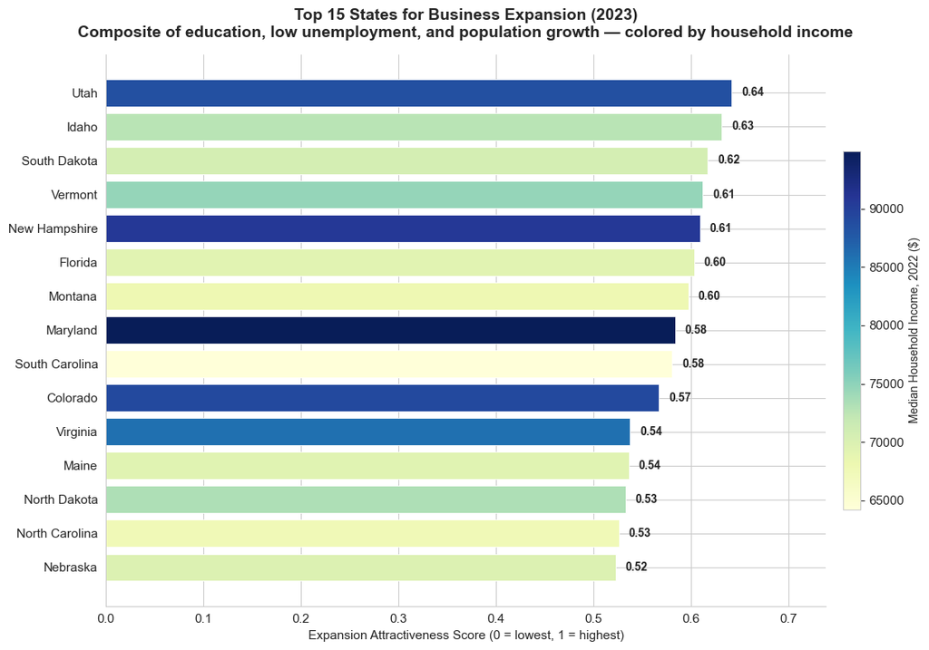

```python
# ============================================================================
# AUDIENCE 1: Corporate Executives looking to expand
# ----------------------------------------------------------------------------
# High-level overview — a ranked horizontal bar chart of the top 15 states
# by composite Expansion_Score. Bar color encodes 2022 median household
# income, adding a market-purchasing-power dimension on top of the ranking.
# Two attributes are integrated in a single, scannable visualization.
# ============================================================================

# Build the top-15 frame
top_states = (
    states_df
    .dropna(subset=["Expansion_Score", "Median_Household_Income_2022"])
    .nlargest(15, "Expansion_Score")
    .sort_values("Expansion_Score")    # ascending so the leader appears at the top
)

fig, ax = plt.subplots(figsize=(12, 8))

# Color each bar by 2022 median household income (a separate attribute from the score)
norm = plt.Normalize(
    vmin=top_states["Median_Household_Income_2022"].min(),
    vmax=top_states["Median_Household_Income_2022"].max()
)
colors = plt.cm.YlGnBu(norm(top_states["Median_Household_Income_2022"]))

bars = ax.barh(
    top_states["Area_Name"],
    top_states["Expansion_Score"],
    color=colors, edgecolor="white", linewidth=0.6
)

# Place the numeric score at the end of each bar
for bar, score in zip(bars, top_states["Expansion_Score"]):
    ax.text(
        bar.get_width() + 0.01,
        bar.get_y() + bar.get_height() / 2,
        f"{score:.2f}",
        va="center", fontsize=10, fontweight="bold"
    )

# Colorbar to explain the color dimension
sm = plt.cm.ScalarMappable(cmap="YlGnBu", norm=norm)
sm.set_array([])
cbar = plt.colorbar(sm, ax=ax, shrink=0.65, pad=0.02)
cbar.set_label("Median Household Income, 2022 ($)", fontsize=10)

ax.set_xlabel("Expansion Attractiveness Score (0 = lowest, 1 = highest)", fontsize=11)
ax.set_title(
    "Top 15 States for Business Expansion (2023)\n"
    "Composite of education, low unemployment, and population growth — colored by household income",
    fontsize=14, fontweight="bold", pad=15
)
ax.set_xlim(0, top_states["Expansion_Score"].max() * 1.15)
ax.spines["top"].set_visible(False)
ax.spines["right"].set_visible(False)

plt.tight_layout()
plt.show()
```

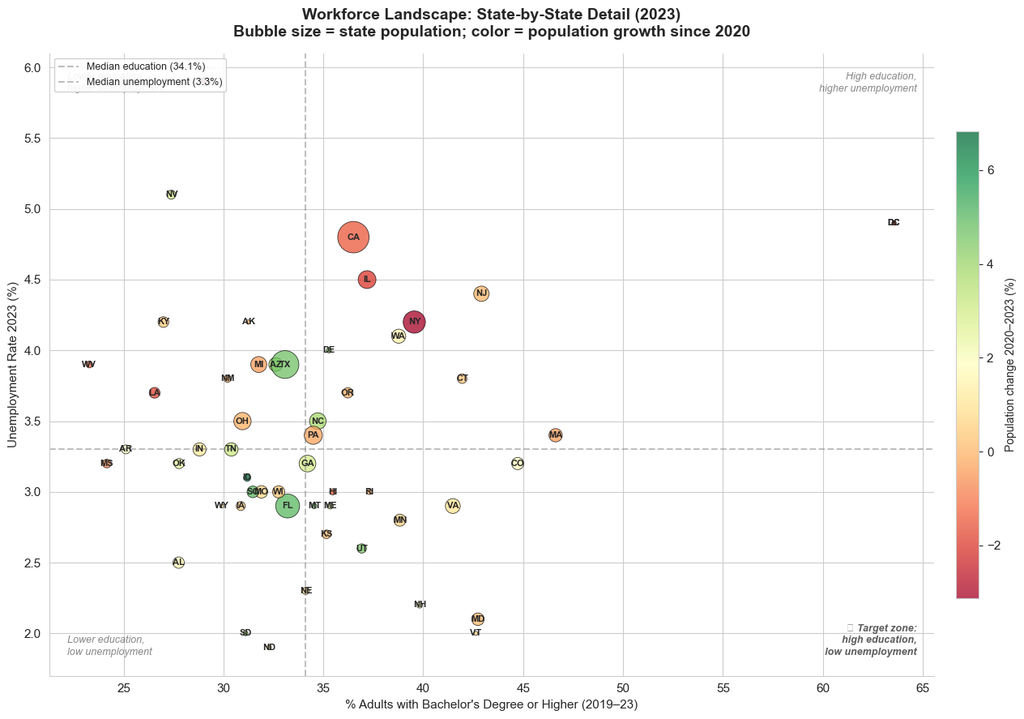

```python
# ============================================================================
# AUDIENCE 2: Local County Commissioners
# ----------------------------------------------------------------------------
# Detailed, multi-attribute view — a bubble scatter plotting every state
# across four dimensions simultaneously:
#   X axis:  % adults with bachelor's degree or higher (2019-23)
#   Y axis:  unemployment rate, 2023
#   Size:    2023 population estimate
#   Color:   population change 2020-2023 (%)
# Median reference lines split the chart into quadrants for fast positioning.
# ============================================================================

plot_data = states_df.dropna(subset=[
    "Percent of adults with a bachelor's degree or higher, 2019-23",
    "Unemployment_rate_2023",
    "POP_ESTIMATE_2023",
    "Pop_Change_Pct_2020_2023"
]).copy()

fig, ax = plt.subplots(figsize=(14, 9))

scatter = ax.scatter(
    plot_data["Percent of adults with a bachelor's degree or higher, 2019-23"],
    plot_data["Unemployment_rate_2023"],
    s=plot_data["POP_ESTIMATE_2023"] / 50000,
    c=plot_data["Pop_Change_Pct_2020_2023"],
    cmap="RdYlGn",
    alpha=0.75,
    edgecolors="black", linewidth=0.6
)

# Label each bubble with the state's two-letter abbreviation
for _, row in plot_data.iterrows():
    ax.annotate(
        row["State"],
        (row["Percent of adults with a bachelor's degree or higher, 2019-23"],
         row["Unemployment_rate_2023"]),
        fontsize=8, ha="center", va="center", fontweight="bold"
    )

# Median reference lines
nat_edu   = plot_data["Percent of adults with a bachelor's degree or higher, 2019-23"].median()
nat_unemp = plot_data["Unemployment_rate_2023"].median()
ax.axvline(nat_edu,   linestyle="--", color="gray", alpha=0.5,
            label=f"Median education ({nat_edu:.1f}%)")
ax.axhline(nat_unemp, linestyle="--", color="gray", alpha=0.5,
            label=f"Median unemployment ({nat_unemp:.1f}%)")

# Quadrant annotations
ax.text(0.98, 0.97, "High education,\nhigher unemployment",
        transform=ax.transAxes, ha="right", va="top",
        fontsize=9, alpha=0.55, style="italic")
ax.text(0.02, 0.97, "Lower education,\nhigher unemployment",
        transform=ax.transAxes, ha="left", va="top",
        fontsize=9, alpha=0.55, style="italic")
ax.text(0.98, 0.03, "★ Target zone:\nhigh education,\nlow unemployment",
        transform=ax.transAxes, ha="right", va="bottom",
        fontsize=9, alpha=0.75, style="italic", fontweight="bold")
ax.text(0.02, 0.03, "Lower education,\nlow unemployment",
        transform=ax.transAxes, ha="left", va="bottom",
        fontsize=9, alpha=0.55, style="italic")

# Colorbar for the growth dimension
cbar = plt.colorbar(scatter, ax=ax, shrink=0.75, pad=0.02)
cbar.set_label("Population change 2020–2023 (%)", fontsize=10)

ax.set_xlabel("% Adults with Bachelor's Degree or Higher (2019–23)", fontsize=11)
ax.set_ylabel("Unemployment Rate 2023 (%)", fontsize=11)
ax.set_title(
    "Workforce Landscape: State-by-State Detail (2023)\n"
    "Bubble size = state population; color = population growth since 2020",
    fontsize=14, fontweight="bold", pad=15
)
ax.legend(loc="upper left", fontsize=9, framealpha=0.9)
ax.spines["top"].set_visible(False)
ax.spines["right"].set_visible(False)

plt.tight_layout()
plt.show()
```